# Reproduction of hypothesis-generating data analyses in Ma17JNCI

John Lövrot

April 18, 2017

# Aim

The aim of this report is to reproduce the hypothesis-generating data analyses in the original research article by Ma, Karthik, Lövrot, et al.<sup>1</sup>

# Background

Breast cancer stem-like cells (BSC).

# Data aquisition

> To further explore ERβ function in BSCs, we performed whole-transcriptome analysis of mammospheres (MCF7S) incubated with vehicle control, or 10nM DPN.

All the procedures and Affymetrix CEL files are available through the Gene Expression Omnibus (GEO) Database under accession number GSE56139.

# Data munging

## Microarray data preprocessing

Affymetrix microarray CEL files for GSE56139 was retrieved using the [GEOquery](https://bioconductor.org/packages/GEOquery/) package<sup>2</sup>. Probe intensities were extracted from CEL files and background corrected, normalized and summarized to probeset expression using the `rma` function from the [oligo](https://bioconductor.org/packages/oligo/) package<sup>3</sup> with the default settings. Probesets were mapped to Entrez Gene IDs using the [hta20transcriptcluster.db](http://bioconductor.org/packages/hta20transcriptcluster.db/) package.

Asssembled R/Bioconductor ExpressionSet object:

```
## ExpressionSet (storageMode: lockedEnvironment)
## assayData: 70523 features, 16 samples
##   element names: exprs
## protocolData
##   rowNames: RM01 RM02 ... RM16 (16 total)
##   varLabels: exprs dates
##   varMetadata: labelDescription channel
## phenoData
##   rowNames: RM01 RM02 ... RM16 (16 total)
##   varLabels: geo_accession arraycd ... celnam (8 total)
##   varMetadata: labelDescription channel
## featureData
##   featureNames: 2824546_st 2824549_st ... TCUn_gl000247000001.hg.1
##     (70523 total)
##   fvarLabels: probeid entrezid symbol
##   fvarMetadata: labelDescription
## experimentData: use 'experimentData(object)'
## Annotation: hta20transcriptcluster
```

Table. Characteristics of the full gene-expression dataset GSE56139.

| geo_accession | arraycd | cellcd | armcd | arm | replicate |
| --- | --- | --- | --- | --- | --- |
| GSM1356480 | RM01 | MCF7S | D | DPN | 1 |
| GSM1356481 | RM02 | MCF7S | D | DPN | 2 |
| GSM1356482 | RM03 | MCF7S | D | DPN | 3 |
| GSM1356483 | RM04 | MCF7S | P | DPN/PHTPP | 1 |
| GSM1356484 | RM05 | MCF7S | P | DPN/PHTPP | 2 |
| GSM1356485 | RM06 | MCF7S | P | DPN/PHTPP | 3 |
| GSM1356486 | RM07 | MCF7S | C | Control | 1 |
| GSM1356487 | RM08 | MCF7S | C | Control | 2 |
| GSM1356488 | RM09 | MCF7S | C | Control | 3 |
| GSM1356489 | RM10 | MCF7S | C | Control | 4 |
| GSM1356490 | RM11 | MCF7 | C | Control | 1 |
| GSM1356491 | RM12 | MCF7 | C | Control | 2 |
| GSM1356492 | RM13 | MCF7 | C | Control | 3 |
| GSM1356493 | RM14 | MCF7 | D | DPN | 1 |
| GSM1356494 | RM15 | MCF7 | D | DPN | 2 |
| GSM1356495 | RM16 | MCF7 | D | DPN | 3 |

# Data analysis

## Initial data explorations

Initial explorations of the transcriptomic data for mammospheres (MCF7S) incubated with vehicle control and 10nM DPN.

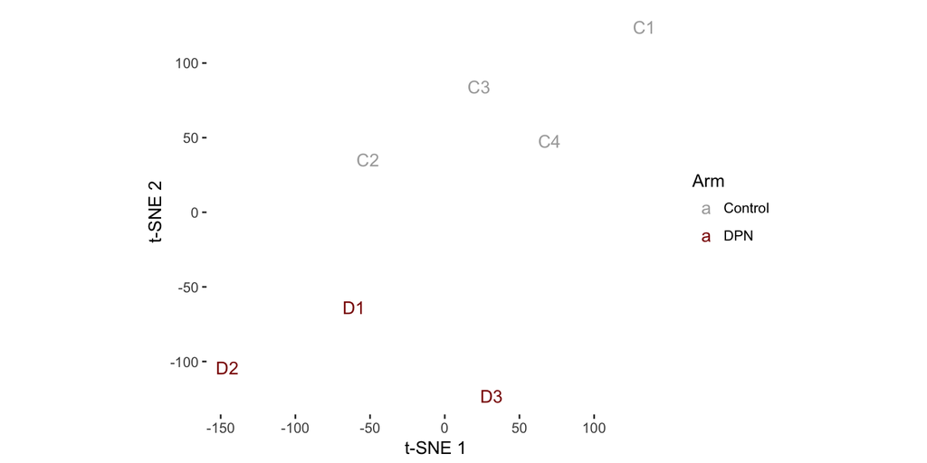

Figure. t-distributed stochastic neighbour embedding (t-SNE) plot.

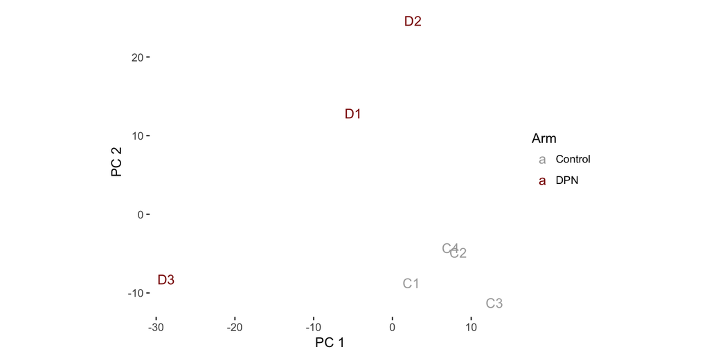

Figure. Conventional principal component analysis (PCA) plot after mean centering the variables/genes.

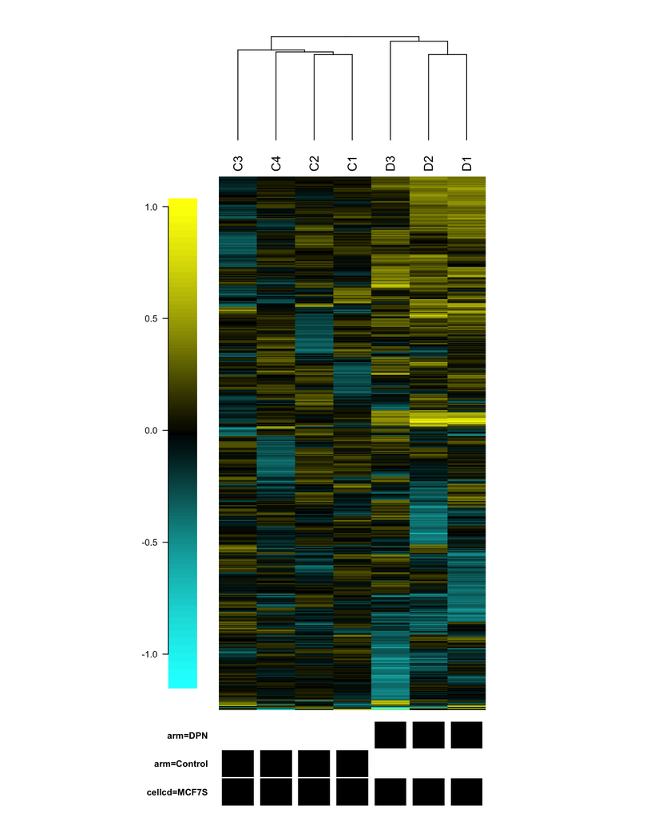

Figure. Exploratory cluster heatmap. Unsupervised clustering of the samples based on the top 500 most varying genes. Average-linkage hierarchical clustering using the Euclidean distance metric, after gene-centering using the average of controls. Yellow: higher than average gene-expression in controls; black: average in controls; blue: lower than average in controls

Since expression values are log2 transformed intensity values, a difference in expression by one unit corresponds to a two-fold mean change in probe intensities.

## Differential expression analysis

Expression data was collapsed to gene level using a non-specific filter keeping only the probesets with highest interquartile range in the case of multiple mappings to the same Entrez Gene ID.

```r
eset <- genefilter::featureFilter(erbeta)
```

DPN induced changes in gene expression were assessed with moderated t-tests using the [limma](https://bioconductor.org/packages/limma/) package<sup>4</sup>. Multiple testing was controlled by calculating the expected false discovery rate (FDR) according to Benjamini & Hochberg.

```r
eset <- eset[, eset$cellcd == "MCF7S" & eset$armcd %in% c("C", "D")]
eset$armcd <- eset$armcd[drop = TRUE]

design <- model.matrix(~ armcd, data = pData(eset))
fit <- lmFit(eset, design)
fit <- contrasts.fit(fit, coefficients = "armcdD")
fit <- eBayes(fit)
tab <- topTable(fit, number = nrow(eset), adjust.method = "BH")
```

> Transcriptome changes after DPN treatment in MCF7S revealed a distinct gene expression pattern: 75 transcripts were differentially regulated upon DPN treatment compared to the control group (moderated t-tests, nominal P < 0.0005, FDR ≈ 0.15).

```r
nrow(filter(tab, P.Value < 0.0005))
```

```
## [1] 75
```

```r
max(filter(tab, P.Value < 0.0005)$adj.P.Val)  # FDR
```

```
## [1] 0.1535106
```

Table. Top 5 differentially abundant transcripts.

| symbol | entrezid | logFC | AveExpr | t | P.Value | adj.P.Val |
| --- | --- | --- | --- | --- | --- | --- |
| FUT11 | 170384 | 0.5260097 | 9.210358 | 11.242123 | 1.70e-06 | 0.0347493 |
| STC2 | 8614 | 0.3446765 | 8.898791 | 10.497729 | 3.00e-06 | 0.0347493 |
| CDCA7L | 55536 | 0.2612691 | 7.183343 | 7.783524 | 3.22e-05 | 0.1095557 |
| SFXN3 | 81855 | 0.3945605 | 8.616041 | 7.700908 | 3.49e-05 | 0.1095557 |
| PPFIA4 | 8497 | 0.2849207 | 7.653035 | 7.432418 | 4.59e-05 | 0.1095557 |

## Gene set enrichment analysis

> To assess the biological relevance of the distinct gene expression pattern, we performed gene set enrichment analyses (GSEA) of the canonical pathways gene-set collection in the Molecular Signatures Database (Broad Institute). Seven gene sets were significantly enriched in DPN-treated mammospheres as compared to control (FDR < 0.10, Supplementary Table 3) with the majority related to glycolytic metabolism and with REACTOME_GLYCOLYSIS as top pathway (FDR < 0.001, Figure 4A).

Enrichment analyses of canonical pathways gene-set collections in the [Molecular Signatures Database](http://software.broadinstitute.org/gsea/msigdb/) (Broad Institute) were performed using the [GSEA Software](http://software.broadinstitute.org/gsea/) (Broad Institute)<sup>5</sup> with genes pre-ranked according to the moderated t-test statistics.

Table. Canonical pathways gene-sets significantly enriched in DPN-treated mammospheres as compared to control (FDR < 0.05).

| NAME | SIZE | ES | NES | NOM.p.val | FDR.q.val |
| --- | --- | --- | --- | --- | --- |
| REACTOME_GLYCOLYSIS | 27 | 0.742 | 2.461 | 0 | 0.000 |
| REACTOME_RNA_POL_I_PROMOTER_OPENING | 50 | 0.634 | 2.459 | 0 | 0.000 |
| PID_HIF1_TFPATHWAY | 65 | 0.599 | 2.400 | 0 | 0.000 |
| REACTOME_AMYLOIDS | 69 | 0.562 | 2.260 | 0 | 0.001 |
| REACTOME_PACKAGING_OF_TELOMERE_ENDS | 43 | 0.613 | 2.253 | 0 | 0.001 |
| REACTOME_DEPOSITION_OF_NEW_CENPA_CONTAINING_NUCLEO | 56 | 0.558 | 2.203 | 0 | 0.001 |
| REACTOME_GLUCOSE_METABOLISM | 63 | 0.525 | 2.076 | 0 | 0.005 |
| KEGG_STARCH_AND_SUCROSE_METABOLISM | 38 | 0.561 | 2.012 | 0 | 0.009 |
| BIOCARTA_MTA3_PATHWAY | 18 | 0.668 | 1.954 | 0 | 0.019 |
| KEGG_GLYCOLYSIS_GLUCONEOGENESIS | 62 | 0.491 | 1.944 | 0 | 0.019 |
| KEGG_SYSTEMIC_LUPUS_ERYTHEMATOSUS | 120 | 0.428 | 1.891 | 0 | 0.032 |

N.B. There are slight differences in GSEA results between the original analysis and this reproduction. The original analysis was performed using R version 3.2.3, in particular the hta20sttranscriptcluster.db annotation package (version 8.3.1) was used. Here, we’ve instead used the hta20transcriptcluster.db annotation package – no “st” in the package name – as of R version 3.3 and higher, see https://support.bioconductor.org/p/91448/.

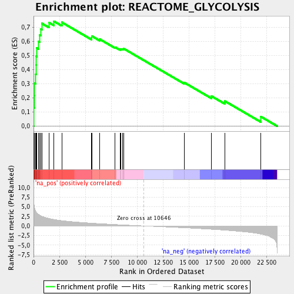

Figure. Enrichment plot for the REACTOME_GLYCOLYSIS gene-set.

© 2017 John Lövrot.  
This work is licensed under a [Creative Commons Attribution 4.0 International License](http://creativecommons.org/licenses/by/4.0/).  
The source code is available at github.com/lovrot/reproduce-ma17jnci.  
Version 0.0.0.9000

# References

1. Ma R, Karthik G-M, Lövrot J, et al. Estrogen receptor β as a therapeutic target in breast cancer stem cells. *J Natl Cancer Inst*. 2017;109(3):1-14. doi:10.1093/jnci/djw236.

2. Davis S, Meltzer PS. GEOquery: a bridge between the Gene Expression Omnibus (GEO) and BioConductor. *Bioinformatics*. 2007;23(14):1846-1847. doi:10.1093/bioinformatics/btm254.

3. Carvalho BS, Irizarry RA. A framework for oligonucleotide microarray preprocessing. *Bioinformatics*. 2010;26(19):2363-2367. doi:10.1093/bioinformatics/btq431.

4. Ritchie ME, Phipson B, Wu D, et al. limma powers differential expression analyses for RNA-sequencing and microarray studies. *Nucleic Acids Res*. 2015;43(7):e47-e47. doi:10.1093/nar/gkv007.

5. Subramanian A, Tamayo P, Mootha VK, et al. Gene set enrichment analysis: a knowledge-based approach for interpreting genome-wide expression profiles. *Proc Natl Acad Sci U S A*. 2005;102(43):15545-15550. doi:10.1073/pnas.0506580102.